# ЕГЭ 2017 Вариант 9 EGE 2017 Variant 9

## 15.

На рисунке — схема дорог, связывающих города $А, Б, В, Г, Д, Е, Ж, 3, И, К$.

По каждой дороге можно двигаться только в одном направлении, указанном стрелкой.

Сколько существует различных путей из города $А$ в город $К$?

In the figure - the scheme of roads is connecting the cities $А, Б, В, Г, Д, Е, Ж, З, И, К$.

For each road, it is possible to move only in one direction, indicated by an arrow.

How many different paths exist from the city $А$ to the city $К$?

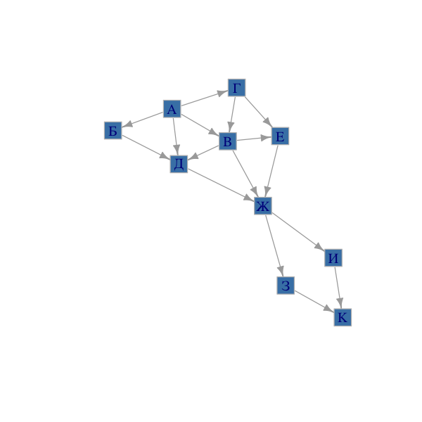

```r
options(warn = -1,repr.plot.width=5,repr.plot.height=5)
edges <- c('А','Б', 'А','В', 'А','Г', 'А','Д', 'Б','Д',
           'В','Д', 'В','Е', 'В','Ж', 'Г','В', 'Г','Е',
           'Д','Ж', 'Е','Ж',
           'Ж','И', 'Ж','З', 'З','К', 'И','К')
g2 <- graph(edges)
plot(g2,
     vertex.color="steelblue",vertex.size=15,
     vertex.frame.color="gray",vertex.shape='square')
```

```r
paths <- all_simple_paths(g2,'А','К')
paths <- lapply(1:length(paths), function(x) as_ids(paths[[x]]))
paths
```

1. 1. 'А'

   2. 'Б'

   3. 'Д'

   4. 'Ж'

   5. 'И'

   6. 'К'

2. 1. 'А'

   2. 'Б'

   3. 'Д'

   4. 'Ж'

   5. 'З'

   6. 'К'

3. 1. 'А'

   2. 'В'

   3. 'Д'

   4. 'Ж'

   5. 'И'

   6. 'К'

4. 1. 'А'

   2. 'В'

   3. 'Д'

   4. 'Ж'

   5. 'З'

   6. 'К'

5. 1. 'А'

   2. 'В'

   3. 'Е'

   4. 'Ж'

   5. 'И'

   6. 'К'

6. 1. 'А'

   2. 'В'

   3. 'Е'

   4. 'Ж'

   5. 'З'

   6. 'К'

7. 1. 'А'

   2. 'В'

   3. 'Ж'

   4. 'И'

   5. 'К'

8. 1. 'А'

   2. 'В'

   3. 'Ж'

   4. 'З'

   5. 'К'

9. 1. 'А'

   2. 'Г'

   3. 'В'

   4. 'Д'

   5. 'Ж'

   6. 'И'

   7. 'К'

10. 1. 'А'

    2. 'Г'

    3. 'В'

    4. 'Д'

    5. 'Ж'

    6. 'З'

    7. 'К'

11. 1. 'А'

    2. 'Г'

    3. 'В'

    4. 'Е'

    5. 'Ж'

    6. 'И'

    7. 'К'

12. 1. 'А'

    2. 'Г'

    3. 'В'

    4. 'Е'

    5. 'Ж'

    6. 'З'

    7. 'К'

13. 1. 'А'

    2. 'Г'

    3. 'В'

    4. 'Ж'

    5. 'И'

    6. 'К'

14. 1. 'А'

    2. 'Г'

    3. 'В'

    4. 'Ж'

    5. 'З'

    6. 'К'

15. 1. 'А'

    2. 'Г'

    3. 'Е'

    4. 'Ж'

    5. 'И'

    6. 'К'

16. 1. 'А'

    2. 'Г'

    3. 'Е'

    4. 'Ж'

    5. 'З'

    6. 'К'

17. 1. 'А'

    2. 'Д'

    3. 'Ж'

    4. 'И'

    5. 'К'

18. 1. 'А'

    2. 'Д'

    3. 'Ж'

    4. 'З'

    5. 'К'

```r
answer_dictionary[15] <- toString(length(paths))
```

## 16.

В системе счисления с основанием 7 записано трёхзначное число. Известно, что все цифры числа разные.

Какое самое большое число удовлетворяет этому условию? Ответ запишите в десятичной системе счисления.

In the number system with base 7, a three-digit number is written. It is known that all figures of the number are different.

What is the largest number that satisfies this condition? Write the answer in decimal notation.

```r
6 * 7 ** 2 + 5 * 7 ** 1 + 4 * 7 ** 0
```

333

```r
sep2dec <- function(n) {
  return(sapply(strsplit(as.character(n),split=""),
                function(x) sum(as.numeric(x) * 7 ** (rev(seq_along(x) - 1)))))
}
```

```r
answer_dictionary[16] <- toString(sep2dec('654'))
```

## 17.

В языке запросов к поисковому серверу для обозначения

- логической операции $«ИЛИ»$ используется символ $" \mid "$,
- а для логической операции $«И»$ — $" \& "$.

В таблице приведено количество страниц, которое находит поисковая система по каждому запросу.

In the query language to the search server,

- the symbol $" \mid "$ is used to indicate the logical operation $"OR"$,
- and for the logical operation $"AND"$ - $" \& "$.

The table shows the number of pages that the search engine finds for each query.

| Запрос | Количество найденных страниц (в тысячах) |
| --- | --- |
| Query | Number of Found Pages |
| *Красный* | 21 |
| *Синий* | 34 |
| *Зелёный* | 28 |
| *Красный* $\&$ *Зелёный* | 6 |
| *Синий* $\&$ *Зелёный* | 11 |
| *Красный* $\mid$ *Синий* $\mid$ *Зелёный* | 61 |
| *Красный* $\&$ *Синий* $\&$ *Зелёный* | 2 |

Какое количество страниц (в тысячах) будет найдено этой поисковой системой по запросу *Красный* $\&$ *Синий*?

How many pages (in thousands) will be found on the query *Красный* $\&$ *Синий*?

*Красный* $\mid$ *Синий* $\mid$ *Зелёный* $=$

$=$ *Красный* $+$ *Зелёный* $+$ *Синий* $-$ *Красный* $\&$ *Зелёный* $-$ *Синий* $\&$ *Зелёный* $-$ *Красный* $\&$ *Синий* $+$ *Красный* $\&$ *Синий* $\&$ *Зелёный*

*Красный* $\&$ *Синий* $=$

$=$ *Красный* $+$ *Зелёный* $+$ *Синий* $-$ *Красный* $\&$ *Зелёный* $-$ *Синий* $\&$ *Зелёный* $-$ *Красный* $\mid$ *Синий* $\mid$ *Зелёный* $+$ *Красный* $\&$ *Синий* $\&$ *Зелёный*

```r
Red <- 21; Green <- 28; Blue <- 34
Red_and_Green <- 6
Blue_and_Green <- 11
Red_and_Green_and_Blue <- 2
Red_or_Green_or_Blue <- 61

Red_and_Blue <- Red + Green + Blue -
                Red_and_Green - Blue_and_Green - Red_or_Green_or_Blue +
                Red_and_Green_and_Blue
Red_and_Blue
```

7

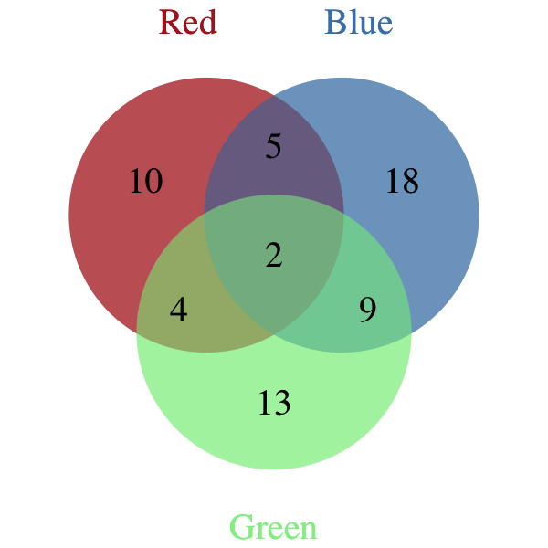

```r
venn.plot <- draw.triple.venn(
    area1 = Red, area2 = Blue, area3 = Green,
    n12 = Red_and_Blue, n23 = Blue_and_Green, n13 = Red_and_Green,
    n123 = Red_and_Green_and_Blue,
    category = c("Red", "Blue", "Green"),
    fill = c("firebrick", "steelblue", "lightgreen"),
    lty = "blank",
    cex = 2, cat.cex = 2,
    cat.dist = c(0.1, 0.1, -0.5), cat.pos = c(-5, 5, 0),
    cat.col = c("firebrick", "steelblue", "lightgreen")
);
grid.draw(venn.plot);
grid.newpage();
```

```r
answer_dictionary[17] <- toString(Red_and_Blue)
```

## 18.

Обозначим через $ДЕЛ(n, m)$ утверждение «натуральное число $n$ делится без остатка на натуральное число $m$».

Для какого наибольшего натурального числа $A$ формула

$\neg ДЕЛ(x, A) \to (ДЕЛ(x, 6) \to \neg ДЕЛ(x, 8))$

тождественно истинна (то есть принимает значение $1$ при любом натуральном значении переменной $x$)?

Let's denote by $ДЕЛ(n, m)$ the statement "a natural number $n$ is divisible without remainder by a natural number $m$".

What is the largest natural number $A$, for which the formula

$\neg ДЕЛ(x, A) \to (ДЕЛ(x, 6) \to \neg ДЕЛ(x, 8))$

is identically true (that is, it takes the value $1$ for any natural value of the variable $x$)?

$\neg ДЕЛ(x, A) \to (ДЕЛ(x, 6) \to \neg ДЕЛ(x, 8)) \iff \\ \neg \neg ДЕЛ(x, A) \lor (ДЕЛ(x, 6) \to \neg ДЕЛ(x, 8)) \iff \\ ДЕЛ(x, A) \lor (\neg ДЕЛ(x, 6) \lor \neg ДЕЛ(x, 8)) \iff \\ ДЕЛ(x, A) \lor \neg (ДЕЛ(x, 6) \land ДЕЛ(x, 8)) \iff \\ ДЕЛ(x, A) \lor \neg ДЕЛ(x, 24) \ (*)$

$(*) \equiv TRUE \iff ДЕЛ(x, A) \equiv ДЕЛ(x, 24)$

```r
answer_dictionary[18] <- toString(2 * 3 * 4)
```

## 19.

В программе используется целочисленный массив $A$ с индексами от $0$ до $9$.

Значения элементов массива равны $6; 5; 4; 7; 10; 6; 9; 11; 7; 8$ соответственно, т.е. $А[0] = 6; А[1] = 5$ и т.д.

Определите значение переменной $k$ после выполнения следующего фрагмента программы,

записанной ниже на разных языках программирования.

The program uses an integer array $A$ with indices from $0$ to $9$.

The values of the array elements are $6, 5, 4, 7, 10, 6, 9, 11, 7, 8$ respectively, i.e. $A[0] = 6$; $A[1] = 5$, etc.

Determine the value of the variable $k$ after the execution of the next program fragment,

written down below in different programming languages.

Python

R

```python
A = [6,5,4,7,10,6,9,11,7,8]
k = 0

for i in range(10):
    if A[i] % 2 > 0:
        k = i
```

```r
A <- c(6,5,4,7,10,6,9,11,7,8)
k <- 0

for (i in 1:10) {
    if (A[i] %% 2 > 0) {
        k <- i - 1
    }
}
```

```r
A <- c(6,5,4,7,10,6,9,11,7,8)
k <- 0

for (i in 1:10) {
    if (A[i] %% 2 > 0) {
        k <- i-1
    }
}

k
```

8

```r
answer_dictionary[19] <- toString(k)
```

## 20.

Ниже на нескольких языках записан алгоритм.

Получив на вход число $х$, этот алгоритм печатает три числа $K$, $M$ и $L$.

Укажите наименьшее число $х$, при вводе которого алгоритм печатает сначала $3$, потом $2$, потом ещё $2$.

Below, in several languages, the algorithm is written.

After receiving the number $x$ on the input, this algorithm prints three numbers $K$, $M$ and $L$.

Specify the smallest number $x$, for which the algorithm prints at first $3$, and then $2$, and $2$ else.

Python

R

```python
x = int(input())
K, L, M = 0, 0, 0

while x > 0:
    y = x % 10
    K += 1
    if y % 3 == 0:
        L += 1
    if y % 5 == 0:
        M += 1
    x = x // 10

print(K, L, M)
```

```r
x <- as.integer(readline())
K <- 0; L <- 0; M <- 0

while (x > 0) {
    y <- x %% 10
    K = K + 1
    if (y %% 3 == 0) {
        L <- L + 1
    }
    if (y %% 5 == 0) {
        M <- M + 1
    }
    x <- x %/% 10
}

print(sprintf("%i %i %i", K, L, M))
```

```r
x <- as.integer(readline())
K <- 0; L <- 0; M <- 0

while (x > 0) {
    y <- x %% 10
    K = K + 1
    if (y %% 3 == 0) {
        L <- L + 1
    }
    if (y %% 5 == 0) {
        M <- M + 1
    }
    x <- x %/% 10
}

print(sprintf("%i %i %i", K, L, M))
```

```
100
[1] "3 2 2"
```

```r
# расширенная версия программы
for (x in 90:110) {
    K <- 0; L <- 0; M <- 0; t <- x

    while (x > 0) {
        y <- x %% 10
        K = K + 1
        if (y %% 3 == 0) {
            L <- L + 1
        }
        if (y %% 5 == 0) {
            M <- M + 1
        }
        x <- x %/% 10
    }

    print(sprintf("%i %i %i %i", t, K, L, M))

    if (K == 3 & L == 2 & M == 2) {
        answer <- toString(t)
    }
}
```

```
[1] "90 2 2 1"
[1] "91 2 1 0"
[1] "92 2 1 0"
[1] "93 2 2 0"
[1] "94 2 1 0"
[1] "95 2 1 1"
[1] "96 2 2 0"
[1] "97 2 1 0"
[1] "98 2 1 0"
[1] "99 2 2 0"
[1] "100 3 2 2"
[1] "101 3 1 1"
[1] "102 3 1 1"
[1] "103 3 2 1"
[1] "104 3 1 1"
[1] "105 3 1 2"
[1] "106 3 2 1"
[1] "107 3 1 1"
[1] "108 3 1 1"
[1] "109 3 2 1"
[1] "110 3 1 1"
```

```r
answer_dictionary[20] <- answer
```

## 21.

Ниже на нескольких языках представлен алгоритм.

Определите, при скольких значениях $b$ на экран будет выведено такое же число, как и при $b = 200$ (включая $b = 200$).

The algorithm is presented in several languages below.

Determine for how many values of $b$ the same number will be displayed on the screen as for $b = 200$ (including $b = 200$).

Python

R

```python
def F(x):
    if x == 0:
        return 0
    else:
        return F(x // 2) + 1

b = int(input())
a = 0
while a < F(b):
    a += 1

print(a)
```

```r
F <- function(x) {
    if (x == 0) {
        return (0)
    } else {
        return(F(x %/% 2) + 1)
    }
}

b <- as.integer(readline())
a <- 0

while (a < F(b)) {
    a <- a + 1
}

print(a)
```

```r
F <- function(x) {
    if (x == 0) {
        return (0)
    } else {
        return(F(x %/% 2) + 1)
    }
}

b <- as.integer(readline())
a <- 0

while (a < F(b)) {
    a <- a + 1
}

print(a)
```

```
200
[1] 8
```

Переменная $a$ равна количеству разрядов в бинарной записи числа $b$. Для $b = 200$ переменная $a = 8$.

Такое же значение параметр $a$ будет принимать для всех натуральных $b: 127 < b < 256$.

Количество таких чисел равно $128$.

The variable $a$ is equal to the number of digits in the binary form of $b$. For $b = 200$, the variable $a = 8$.

The same value of the parameter $a$ will be taken for all natural numbers $b: 127 < b < 256$.

The quantity of this type of numbers is $128$.

```r
# расширенная версия программы
F <- function(x) {
    if (x == 0) {
        return (0)
    } else {
        return(F(x %/% 2) + 1)
    }
}

A <- matrix(nrow=2, ncol=160)

for (b in 100:259) {
    a <- 0

    while (a < F(b)) {
        a <- a + 1
    }

    A[1,b-99] <- b
    A[2,b-99] <- a
}

print("Pairs [b,a]:")
print(A)
```

```
[1] "Pairs [b,a]:"
     [,1] [,2] [,3] [,4] [,5] [,6] [,7] [,8] [,9] [,10] [,11] [,12] [,13] [,14]
[1,]  100  101  102  103  104  105  106  107  108   109   110   111   112   113
[2,]    7    7    7    7    7    7    7    7    7     7     7     7     7     7
     [,15] [,16] [,17] [,18] [,19] [,20] [,21] [,22] [,23] [,24] [,25] [,26]
[1,]   114   115   116   117   118   119   120   121   122   123   124   125
[2,]     7     7     7     7     7     7     7     7     7     7     7     7
     [,27] [,28] [,29] [,30] [,31] [,32] [,33] [,34] [,35] [,36] [,37] [,38]
[1,]   126   127   128   129   130   131   132   133   134   135   136   137
[2,]     7     7     8     8     8     8     8     8     8     8     8     8
     [,39] [,40] [,41] [,42] [,43] [,44] [,45] [,46] [,47] [,48] [,49] [,50]
[1,]   138   139   140   141   142   143   144   145   146   147   148   149
[2,]     8     8     8     8     8     8     8     8     8     8     8     8
     [,51] [,52] [,53] [,54] [,55] [,56] [,57] [,58] [,59] [,60] [,61] [,62]
[1,]   150   151   152   153   154   155   156   157   158   159   160   161
[2,]     8     8     8     8     8     8     8     8     8     8     8     8
     [,63] [,64] [,65] [,66] [,67] [,68] [,69] [,70] [,71] [,72] [,73] [,74]
[1,]   162   163   164   165   166   167   168   169   170   171   172   173
[2,]     8     8     8     8     8     8     8     8     8     8     8     8
     [,75] [,76] [,77] [,78] [,79] [,80] [,81] [,82] [,83] [,84] [,85] [,86]
[1,]   174   175   176   177   178   179   180   181   182   183   184   185
[2,]     8     8     8     8     8     8     8     8     8     8     8     8
     [,87] [,88] [,89] [,90] [,91] [,92] [,93] [,94] [,95] [,96] [,97] [,98]
[1,]   186   187   188   189   190   191   192   193   194   195   196   197
[2,]     8     8     8     8     8     8     8     8     8     8     8     8
     [,99] [,100] [,101] [,102] [,103] [,104] [,105] [,106] [,107] [,108]
[1,]   198    199    200    201    202    203    204    205    206    207
[2,]     8      8      8      8      8      8      8      8      8      8
     [,109] [,110] [,111] [,112] [,113] [,114] [,115] [,116] [,117] [,118]
[1,]    208    209    210    211    212    213    214    215    216    217
[2,]      8      8      8      8      8      8      8      8      8      8
     [,119] [,120] [,121] [,122] [,123] [,124] [,125] [,126] [,127] [,128]
[1,]    218    219    220    221    222    223    224    225    226    227
[2,]      8      8      8      8      8      8      8      8      8      8
     [,129] [,130] [,131] [,132] [,133] [,134] [,135] [,136] [,137] [,138]
[1,]    228    229    230    231    232    233    234    235    236    237
[2,]      8      8      8      8      8      8      8      8      8      8
     [,139] [,140] [,141] [,142] [,143] [,144] [,145] [,146] [,147] [,148]
[1,]    238    239    240    241    242    243    244    245    246    247
[2,]      8      8      8      8      8      8      8      8      8      8
     [,149] [,150] [,151] [,152] [,153] [,154] [,155] [,156] [,157] [,158]
[1,]    248    249    250    251    252    253    254    255    256    257
[2,]      8      8      8      8      8      8      8      8      9      9
     [,159] [,160]
[1,]    258    259
[2,]      9      9
```

```r
table(A[2,])
```

```
  7   8   9
 28 128   4
```

```r
answer_dictionary[21] <- toString(table(A[2,])[2])
```

## 22.

У исполнителя *Прибавлятель* три команды, которым присвоены номера:

$1.$ *прибавь 1*,

$2.$ *прибавь 2*,

$3.$ *прибавь 5*.

Первая из них увеличивает число на экране на $1$, вторая — на $2$, третья — на $5$.

Программа для *Прибавлятель* — это последовательность команд.

Сколько есть программ, которые число $2$ преобразуют в число $10$?

The performer *Adder* has three enumerated commands:

$1.$ *add 1*,

$2.$ *add 2*,

$3.$ *add 5*.

The first of them increases the number on the screen by $1$, the second - by $2$, the third - by $5$.

The program for *Adder* is a sequence of commands.

How many programs are there that convert $2$ to $10$?

| Начальное число → Конечное число | Количество программ | Примечание |
| --- | --- | --- |
| Start → End | Number of Programs | Notes |
| 2 → 3 | 1 | `2+1` |
| 2 → 4 | 2 | `2+1`, `2+2` |
| 2 → 5 | 3 | = 2 → 3 + 2 → 4 |
| 2 → 6 | 5 | = 2 → 4 + 2 → 5 |
| 2 → 7 | 9 | = 2 → 5 + 2 → 6 + 1 (`2+5`) |
| 2 → 8 | 15 | = 2 → 6 + 2 → 7 + 2 → 3 |
| 2 → 9 | 26 | = 2 → 7 + 2 → 8 + 2 → 4 |
| 2 → 10 | 44 | = 2 → 8 + 2 → 9 + 2 → 5 |

```r
# пример вариантов программы указанного вида
x <- c(2)

for (i in 0:8) {
    n <- as.integer(length(x) - 3 ** i + 1)
    y1 <- c(); y2 <- c(); y3 <- c();

    for (j in n:length(x)) {
        y1 <- c(y1, x[j] + 1)
        y2 <- c(y2, x[j] + 2)
        y3 <- c(y3, x[j] + 5)
    }

    x <- c(x, y1, y2, y3)
}

length(x)
```

29524

```r
nt <- table(x)
nt
```

```
x
   2    3    4    5    6    7    8    9   10   11   12   13   14   15   16   17
   1    1    2    3    5    9   15   26   44   75  127  207  315  446  616  847
  18   19   20   21   22   23   24   25   26   27   28   29   30   31   32   33
1100 1302 1498 1786 2030 2036 2008 2172 2186 1828 1595 1651 1428  945  799  819
  34   35   36   37   38   39   40   41   42   43   44   47
 539  266  280  253   92   44   72   36    1    9    9    1
```

```r
nt[names(nt) == 10]
```

**10:** 44

```r
answer_dictionary[22] <- '44'
```

## 23.

Сколько существует различных наборов значений логических переменных $x_1, х_2, ... х_7, x_8$,

которые удовлетворяют всем перечисленным ниже условиям?

В ответе не нужно перечислять все различные наборы значений $x_1, х_2, ... х_7, x_8$,

при которых выполнена данная система равенств.

В качестве ответа вам нужно указать количество таких наборов.

How many different sets of values of logical variables $x_1, х_2, ... х_7, x_8$ exist

that satisfy all the conditions listed below?

In the answer it is not necessary to list all the different sets of values $x_1, х_2, ... х_7, x_8$

for which the given system of equations is satisfied.

As an answer, you need to specify only the number of such sets.

- $ (x_1 \land x_2) \lor (x_2 \land x_3) = 0 $ **(1)**
- $ (x_2 \land x_3) \lor (x_3 \land x_4) = 0 $ **(2)**
- $ (x_3 \land x_4) \lor (x_4 \land x_5) = 0 $ **(3)**
- $ (x_4 \land x_5) \lor (x_5 \land x_6) = 0 $ **(4)**
- $ (x_5 \land x_6) \lor (x_6 \land x_7) = 0 $ **(5)**
- $ (x_6 \land x_7) \lor (x_7 \land x_8) = 0 $ **(6)**

$ \begin{cases} (x_1 \land x_2) \lor (x_2 \land x_3) = 0 \\ (x_2 \land x_3) \lor (x_3 \land x_4) = 0 \\ (x_3 \land x_4) \lor (x_4 \land x_5) = 0 \\ (x_4 \land x_5) \lor (x_5 \land x_6) = 0 \\ (x_5 \land x_6) \lor (x_6 \land x_7) = 0 \\ (x_6 \land x_7) \lor (x_7 \land x_8) = 0 \end{cases} \iff \begin{cases} x_2 \land (x_1 \lor x_3) = 0 \ (1*) \\ x_3 \land (x_2 \lor x_4) = 0 \ (2*) \\ x_4 \land (x_3 \lor x_5) = 0 \ (3*) \\ x_5 \land (x_4 \lor x_6) = 0 \ (4*) \\ x_6 \land (x_5 \lor x_7) = 0 \ (5*) \\ x_7 \land (x_6 \lor x_8) = 0 \ (6*) \end{cases}$

1) Тождество $(1*)$ выполнется только для 5 наборов переменных $(x_1,x_2,x_3)$ из 8 возможных:

(0,0,0), (0,1,0), (1,0,0), (1,0,1), (0,0,1).

2) Эти наборы $(x_1,x_2,x_3)$ должны пересекаться со множеством решений тождества $(2*)$ для переменных $(x_2,x_3,x_4)$.

Два набора $(x_1,x_2,x_3)$ (1,0,1), (0,0,1) могут быть решениями $(2*)$ только, если $(x_1,x_2,x_3,x_4)$ равны (1,0,1,0) или (0,0,1,0) соответственно.

Для остальных 3 наборов $(x_1,x_2,x_3)$ переменная $x_4$ может принимать любые значения.

Всего решениями системы уравнений $(1∗)$ и $(2∗)$ являются `2 + 3 ∗ 2 = 8` наборов переменных $(x_1,x_2,x_3,x_4)$.

3) Рассуждая аналогично, получим:

- `3 + 5 ∗ 2 = 13` наборов $(x_1,x_2,x_3,x_4,x_5)$, являющихся решениями системы $(1∗), (2∗), (3∗)$;
- `5 + 8 ∗ 2 = 21` набор $(x_1,x_2,x_3,x_4,x_5,x_6)$, являющихся решениями системы $(1∗), (2∗), (3∗), (4*)$;
- `8 + 13 ∗ 2 = 34` набора $(x_1,x_2,x_3,x_4,x_5,x_6,x_7)$, являющихся решениями системы $(1∗), (2∗), (3∗), (4*), (5*)$;
- `13 + 21 ∗ 2 = 55` наборов $(x_1,x_2,x_3,x_4,x_5,x_6,x_7,x_8)$, являющихся решениями системы $(1∗), (2∗), (3∗), (4*), (5*), (6*)$.

1) The identity $(1*)$ is fulfilled only for 5 sets of variables $(x_1,x_2,x_3)$ from 8 possible ones:

(0,0,0), (0,1,0), (1,0,0), (1,0,1), (0,0,1).

2) These sets $(x_1, x_2, x_3)$ must intersect the set of solutions of the identity $(2*)$ for the variables $(x_2, x_3, x_4)$.

Two sets $(x_1, x_2, x_3)$ ((1,0,1), (0,0,1) can be solutions of $(2 *)$ only if $(x_1, x_2, x_3, x_4)$ are equal to (1,0,1,0) or (0,0,1,0) respectively.

For the remaining 3 sets $(x_1, x_2, x_3)$, the variable $x_4$ can take any values.

All solutions of the system of equations $(1 *)$ and $(2 *)$ are `2 + 3 * 2 = 8` sets of variables $(x_1, x_2, x_3, x_4)$.

3) Arguing similarly, we get:

- `3 + 5 ∗ 2 = 13` sets $(x_1,x_2,x_3,x_4,x_5)$ are solutions of the system $(1*), (2*), (3*)$;
- `5 + 8 ∗ 2 = 21` sets $(x_1,x_2,x_3,x_4,x_5,x_6)$ are solutions of the system $(1∗), (2∗), (3∗), (4*)$;
- `8 + 13 ∗ 2 = 34` sets $(x_1,x_2,x_3,x_4,x_5,x_6,x_7)$ are solutions of the system $(1*), (2*), (3*), (4*), (5*)$;
- `13 + 21 ∗ 2 = 55` sets $(x_1,x_2,x_3,x_4,x_5,x_6,x_7,x_8)$ are solutions of the system $(1*), (2*), (3*), (4*), (5*), (6*)$.

```r
# check the decision method
bc <- bincombinations(8)
c <- 0
n <- length(bc)/8

logical_function <- function(k,l,m) {
    (k & l) | (l & m)
}

for (i in 1:n){
    el <- bc[i,]
    e1 <- logical_function(el[1],el[2],el[3])
    e2 <- logical_function(el[2],el[3],el[4])
    e3 <- logical_function(el[3],el[4],el[5])
    e4 <- logical_function(el[4],el[5],el[6])
    e5 <- logical_function(el[5],el[6],el[7])
    e6 <- logical_function(el[6],el[7],el[8])

    result <- (e1 == 0) & (e2 == 0) & (e3 == 0) & (e4 == 0) & (e5 == 0) & (e6 == 0)

    if (result == 1) {
        c <- c + 1
    }
}

c
```

55

```r
answer_dictionary[23] <- toString(c)
```

## Часть 2 Part 2

## 24.

Требовалось написать программу, которая

- вводит с клавиатуры последовательность из n целых чисел (n = 4),
- и выводит на экран сумму отрицательных чисел среди этой последовательности.

Если в последовательности нет отрицательных чисел, программа должна вывести 0.

Известно, что вводимые числа не превышают по модулю 1000.

Программист торопился и написал программу неправильно.

Выполните следующие действия:

1. Напишите, что выведет программа при вводе чисел -1 1 3 -5.
2. Приведите пример такой входной последовательности, при которой программа работает верно.
3. Укажите все ошибки в программе и исправьте их.

Для этого для каждой ошибки: выпишите строку, которая написана неправильно и приведите правильный вариант строки.

It was required to write a program that

- enters from the keyboard a sequence of n integers (n = 4)
- and displays the sum of the negative numbers among this sequence.

If there are no negative numbers in the sequence, the program should output 0.

It is known that the entered numbers do not exceed 1000 by the absolute value.

The programmer was in a hurry and wrote the program incorrectly.

Do the following:

1. Write what the program will output when you enter numbers -1 1 3 -5.
2. Give an example of such an input sequence, for which the program works correctly.
3. Indicate any errors in the program and correct them.

To do this, for each error: write out the line that was written incorrectly and give the correct version of this line.

Python

R

```python
N, SUM = 4, 0

for I in range(N):
    A = int(input())
    if A < 0:
        SUM = A

print(A)
```

```r
N <- 4; SUM <- 0

for (I in 1:N) {
    A <- as.integer(readline())
    if (A < 0) {
        SUM <- A
    }
}

print(A)
```

```r
# the wrong program, the wrong result
N <- 4; SUM <- 0

for (I in 1:N) {
    A <- as.integer(readline())
    if (A < 0) {
        SUM <- A
    }
}

print(A)
```

```
-1
1
3
-5
[1] -5
```

```r
# the wrong program, the right result
N <- 4; SUM <- 0

for (I in 1:N) {
    A <- as.integer(readline())
    if (A < 0) {
        SUM <- A
    }
}

print(A)
```

```
1
2
3
-4
[1] -4
```

```r
# the right program, the right result
N <- 4; SUM <- 0

for (I in 1:N) {
    A <- as.integer(readline())
    if (A < 0) {
        SUM <- SUM + A
    }
}

print(SUM)
```

```
-1
1
3
-5
[1] -6
```

```r
answer_dictionary[24] <- "
1. -5
2. 1 2 3 -4
3. 'SUM <- A' ⟹ 'SUM <- SUM + A'; 'print(A)' ⟹ 'print(SUM)'
"
```

## 25.

Дан целочисленный массив из 40 элементов. Элементы массива могут принимать значения от `-10000` до `10000`.

Опишите на русском языке или на одном из языков программирования алгоритм, который проверяет,

все ли значения элементов массива чётные и положительные.

Если да, программа должна вывести `«YES»`, в противном случае — `«NO»`.

Исходные данные объявлены так, как показано ниже.

Запрещается использовать переменные, не описанные ниже, но разрешается не использовать часть из них.

- Объявляем массив A из 40 элементов.
- Объявляем целочисленные переменные I, J, K.
- В цикле от 1 до 40 вводим элементы массива A с 1-го по 40-й.
- …

В качестве ответа вам необходимо привести фрагмент программы (или описание алгоритма на естественном языке), который должен находиться на месте многоточия.

Вы можете записать решение также на другом языке программирования (укажите название и используемую версию языка программирования, например `Borland Pascal 7.0`) или в виде блок-схемы.

В этом случае вы должны использовать те же самые исходные данные и переменные, какие были предложены в условии (например, в образце, записанном на естественном языке).

An integer array of 40 elements is given. Elements of the array can take values from `-10000` to `10000`.

Describe in Russian / English or in one of the programming languages an algorithm that checks whether all the values of array elements are even and positive.

If yes, the program should output `"YES"`, otherwise `"NO"`.

The original data is declared as shown below.

It is forbidden to use variables not described below, but it is allowed not to use part of them.

- Declare an array A of 40 elements.
- Declare the integer variables I, J, K.
- In the cycle from 1 to 40, we introduce the elements of array A from the 1st to the 40th.
- ...

As an answer, you need to bring the program fragment (or description of the algorithm in the natural language), which should be in place of the ellipsis.

You can also write the solution in another programming language (specify the name and the version of the programming language used, for example, `Borland Pascal 7.0`) or as a flowchart.

In this case, you must use the same source data and variables that were proposed in the condition (for example, in a sample written in the natural language).

Python

R

```python
N = 40
A = []

#use integer variables I, J, K

for I in range(N):
    A.append(int(input()))
    ...
```

```r
N <- 40
A <- vector(mode="integer",length=N)

#use integer variables I, J, K

for (I in 1:N){
    A[I] <- as.integer(readline())
...
}
```

```r
version <- R.version.string
```

```r
cat('Create an integer array of numbers from the interval [-10000, 10000].\n')
N <- 40
A <- vector(mode='integer',length=N)
K <- 0

for (I in 1:N){
    A[I] <- as.integer(readline())
    # The fragment instead of the ellipsis
    if ((A[I] %% 2 != 0) | (A[I] <= 0)) {
        K <- K + 1
    }
}

if (K == 0) {
    cat('YES')
} else {
    cat('NO')
}
```

```
Create an integer array of numbers from the interval [-10000, 10000].
2
4
6
8
10
12
14
16
18
20
22
24
26
28
30
32
34
36
38
40
42
44
46
48
50
52
54
56
58
60
100
200
300
400
500
600
700
800
900
1000
YES
```

```r
program_fragment <- "
cat('Create an integer array of numbers from the interval [-10000, 10000].\n')
N <- 40
A <- vector(mode='integer',length=N)
K <- 0

for (I in 1:N){
    A[I] <- as.integer(readline())
    # The fragment instead of the ellipsis
    if ((A[I] %% 2 != 0) | (A[I] <= 0)) {
        K <- K + 1
    }
}

if (K == 0) {
    cat('YES')
} else {
    cat('NO')
}
"
```

```r
answer_dictionary[25] <- paste(version, program_fragment, sep=";")
```

## 26.

Два игрока, Петя и Ваня, играют в следующую игру. Перед игроками лежит две кучи камней. Игроки ходят по очереди, первый ход делает Петя.

Назовём позицией игры указание количества камней в обеих кучах. Например, позиция `(15,20)` означает, что в первой куче `15` камней, а во второй — `20`.

За один ход игрок может добавить в одну из куч **один** камень или увеличить количество камней в одной из куч в **два** раза.

Например, имея количество камней в кучах `(15,20)`, за один ход можно получить положение `(16,20)`, `(30,20)`, `(15,21)` и `(15,40)`.

У каждого игрока, чтобы делать ходы, есть неограниченное количество камней.

Игра завершается в тот момент, когда количество камней в обеих кучах (сумма) становится **не менее 46**.

Победителем считается игрок, сделавший последний ход, то есть первым получивший положение, в котором сумма камней в кучах будет `46` или больше камней.

Говорят, что игрок имеет выигрышную стратегию, если он может выиграть при любых ходах противника.

Описать стратегию игрока - значит описать, какой ход он должен сделать в любой ситуации, которая ему может встретиться при различной игре противника.

Например, при начальных позициях `(6,20)`, `(5,21)`, `(8,19)` выигрышная стратегия есть у Пети. Чтобы выиграть, ему достаточно удвоить количество камней во второй куче.

Выполните следующие задания. Во всех случаях обосновывайте свой ответ.

$1.$ Для исходных позиций `(5,20)` и `(7,19)` укажите, кто из игроков выигрывает. Сколько ходов необходимо для выигрыша? Опишите выигрышную стратегию. Обоснуйте ответ.

$2.$ Для исходных позиций `(5,19)`, `(6,19)` и `(7,18)` укажите, кто из игроков выигрывает. Сколько ходов необходимо для выигрыша? Опишите выигрышную стратегию. Обоснуйте ответ.

$3.$ Для исходной позиции `(6,18)` укажите, кто из игроков выигрывает. Сколько ходов необходимо для выигрыша? Опишите выигрышную стратегию. Приведите дерево игры. Обоснуйте ответ. На рёбрах дерева указывайте, кто делает ход, в узлах — позицию игры.

Two players, Petya and Vanya, play the next game. There are two heaps of stones in front of the players. Players move by turns, the first step is made by Petya.

Let's call the position of the game the indication of the number of stones in both heaps. For example, position `(15,20)` means that there are `15` stones in the first heap, and `20` in the second one.

In one move, a player can add **one** stone to one of the heaps or **double** the number of stones in one of the heaps.

For example, having the number of stones in heaps `(15,20)`, in one move you can get the position `(16,20)`, `(30,20)`, `(15,21)` and `(15,40)`.

Each player to make moves, there is an unlimited number of stones.

The game ends when the number of stones in both heaps (amount) becomes **at least 46**.

The winner is the player who made the last move, that is, the first to receive the position, in which the number of stones in the heaps will be `46` or more stones.

It is said that a player has a winning strategy if he can win with any moves of the opponent.

To describe a player's strategy is to describe what course he should take in any situation that he can meet in a different game of the opponent.

For example, with the starting positions `(6,20)`, `(5,21)`, `(8,19)` winning strategy is in Petya. To win, it is enough for him to double the number of stones in the second heap.

Complete the following tasks. In all cases, justify your answer.

$1.$ For starting positions `(5,20)` and `(7,19)`, indicate which player wins. How many moves do you need to win? Describe a winning strategy. Justify the answer.

$2.$ For starting positions `(5,19)`, `(6,19)` and `(7,18)`, indicate which player wins. How many moves do you need to win? Describe a winning strategy. Justify the answer.

$3.$ For the starting position `(6,18)`, indicate which player wins. How many moves do you need to win? Describe a winning strategy. Draw the tree of the game. Justify the answer. On the edges of the tree indicate who is making the move, in the nodes - the position of the game.

$1.$ Первый ход делает Петя.

а) Из позиции `(5,20)` он может получить одну из позиций `{(6,20), (10,20), (5,21), (5,40)}`. В любой из них сумма камней меньше `46`. => Ни одна не является выигрышной.

б) Из позиции `(7,19)` он может получить одну из позиций `{(8,19), (14,19), (7,20), (7,38)}`. В любой из них сумма камней меньше 46. => Ни одна не является выигрышной.

Следующий ход делает Ваня.

а) Для любой из позиций после хода Пети Ваня выигрывает: `{(6,20)->(6,40), (10,20)->(10,40), (5,21)->(5,42), (5,40)->(5,80)}`. Ему достаточно удвоить количество камней в одной из куч, сумма камней становится >= `46`.

б) Аналогично: `{(8,19)->(8,38), (14,19)->(14,38), (7,20)->(7,40), (7,38)->(7,76)}`.

Значит, у Вани имеется выигрышная стратегия. Он побеждает при любой из двух начальных позиций, какой бы ход ни выбрал Петя.

$2.$ При стартовых позициях `(5,19), (6,19), (7,18)` у Пети имеется выигрышная стратегия.

Первый ход делает Петя, добавляя один камень: `(5,19)->(5,20), (6,19)->(7,19), (7,18)->(7,19)`.

Следующий ход делает Ваня: `(5,20)->{(6,20), (10,20), (5,21), (5,40)}; (7,19)->{(8,19), (14,19), (7,20), (7,38)}`. Все позиции проигрышные.

Петя при любом из выбранных Ваней вариантов выигрывает, удваивая количество камней: `{(6,20)->(6,40), (10,20)->(10,40), (5,21)->(5,42), (5,40)->(5,80), (8,19)->(8,38), (14,19)->(14,38), (7,20)->(7,40), (7,38)->(7,76)}`.

$3.$ При стартовой позиции `(6,18)` у Вани имеется выигрышная стратегия:

Первые ходы игроков:

Если Петя удваивает количество камней и получает `(12,18)` или `(6,36)`, то Ване достаточно также удвоить их при следующем ходе и получить `(12,36)` или `(6,72)`. Ваня побеждает.

Если Петя добавляет один камень и получает `(7,18)` или `(6,19)`, то Ваня пока победить не может. Однако он не должен допустить победы соперника. Ваня может добавить один камень в любой из этих позиций и перейти в `(7,19)`.

Вторые ходы игроков:

Какой бы ход не сделал Петя `{(8,19), (14,19), (7,20), (7,38)}`, он выиграть не сможет. А Ване достаточно удвоить количество камней при следующем ходе и получить `{(8,38), (14,38), (7,40), (7,76)}`. Ваня побеждает.

$1.$ The first move is made by Petya.

- a) From the position `(5,20)` he can get one of the positions `{(6,20), (10,20), (5,21), (5,40)}`. In any of them the sum of the stones is less than `46`. => None is winning.
- b) From the position `(7,19)` he can obtain one of the positions `{(8,19), (14,19), (7,20), (7,38)}`. In any of them the sum of the stones is less than `46`. => None is winning.

The next move is made by Vanya.

- a) For any of the positions after Petya's move, Vanya wins: `{(6,20)->(6,40), (10,20)->(10,40), (5,21)->(5,42), (5,40)->(5,80)}`. It is enough for him to double the number of stones in one of the piles, the amount of stones becomes >= `46`.
- b) Similarly: `{(8,19)->(8,38), (14,19)->(14,38), (7,20)->(7,40), (7,38)->(7,76)}`.

Hence, Vanya has a winning strategy. He wins at any of two initial positions, no matter what decision Petya has made.

$2.$ With starting positions `(5,19), (6,19), (7,18)` Petya has a winning strategy.

Petya makes the first move, adding one stone: `(5,19)->(5,20), (6,19)->(7,19), (7,18)->(7,19)`.

The next move is made Vanya: `(5,20)->{(6,20), (10,20), (5,21), (5,40)}; (7,19)->{(8,19), (14,19), (7,20), (7,38)}`. All positions are losing.

Petya wins for any of the chosen Vanya variants, doubling the number of stones: `{(6,20)->(6,40), (10,20)->(10,40), (5,21)->(5,42), (5,40)->(5,80), (8,19)->(8,38), (14,19)->(14,38), (7,20)->(7,40), (7,38)->(7,76)}`.

$3.$ With the starting position `(6,18)`, Vanya has a winning strategy:

The first moves of players:

If Petya doubles the number of stones and gets `(12,18)` or `(6,36)`, then it's enough for Vanya to double them in the next move and get `(12,36)` or `(6,72)`. Vanya wins.

If Petya adds one stone and receives `(7,18)` or `(6,19)`, then Vanya cannot win yet. However, he should not allow the opponent to win. Vanya can add one stone to any of these positions and go to `(7,19)`.

The second moves of the players:

Whichever move `{(8,19), (14,19), (7,20), (7,38)}` Petya does, he cannot win. And it's enough for Vanya to double the number of stones at the next step and get `{(8,38), (14,38), (7,40), (7,76)}`. Vanya wins.

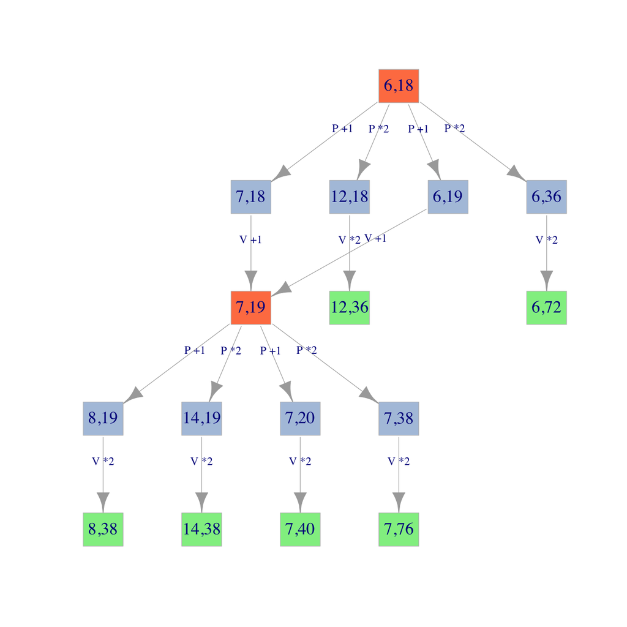

```r
options(repr.plot.width=11,repr.plot.height=11)

edges3 <- c('6,18','7,18', '6,18','12,18', '6,18','6,19', '6,18','6,36',
            '7,18','7,19', '12,18','12,36', '6,19','7,19', '6,36','6,72',
            '7,19','8,19', '7,19','14,19', '7,19','7,20', '7,19','7,38',
            '8,19','8,38', '14,19','14,38', '7,20','7,40', '7,38','7,76')
colors3 <-c ("coral","lightsteelblue","lightsteelblue","lightsteelblue","lightsteelblue",
             "coral","lightgreen","lightgreen",
             "lightsteelblue","lightsteelblue","lightsteelblue","lightsteelblue",
             "lightgreen","lightgreen","lightgreen","lightgreen")
labels3 <- c('P +1','P *2','P +1','P *2','V +1','V *2','V +1','V *2',
             'P +1','P *2','P +1','P *2','V *2','V *2','V *2','V *2')

g3 <- graph(edges3)

plot(g3,layout=layout_as_tree,edge.label=labels3,edge.label.cex=1.2,
     vertex.color=colors3,vertex.size=18,vertex.label.cex=1.8,
     vertex.frame.color="gray",vertex.shape='rectangle');
```

```r
answer_dictionary[26] <- '
1.
a) P:(5,20)->{(6,20), (10,20), (5,21), (5,40)}
   V:{(6,20)->(6,40), (10,20)->(10,40), (5,21)->(5,42), (5,40)->(5,80)}
b) P:(7,19)->{(8,19), (14,19), (7,20), (7,38)}
   V:{(8,19)->(8,38), (14,19)->(14,38), (7,20)->(7,40), (7,38)->(7,76)}
2.
P:(5,19)->(5,20), (6,19)->(7,19), (7,18)->(7,19)
V:(5,20)->{(6,20), (10,20), (5,21), (5,40)} ∨ (7,19)->{(8,19), (14,19), (7,20), (7,38)}
P:{(6,20)->(6,40), (10,20)->(10,40), (5,21)->(5,42), (5,40)->(5,80)} ∨
P:{(8,19)->(8,38), (14,19)->(14,38), (7,20)->(7,40), (7,38)->(7,76)}.
3.
P:(6,18)->{(7,18),(12,18),(6,19),(6,36)}
V:(7,18)->(7,19),(12,18)->(12,36),(6,19)->(7,19),(6,36)->(6,72)
P:(7,19)->{(8,19), (14,19), (7,20), (7,38)}
V:{(8,19)->(8,38),(14,19)->(14,38),(7,20)->(7,40),(7,38)->(7,76)}'
```

## 27.

На вход программе подаётся: в первой строке — число $N \ (5 < N < 10^9)$.

В каждой из последующих N строк — по одному элементу последовательности — натуральные числа, не превышающее $10^9$.

Напишите эффективную, в том числе и по используемой памяти, программу (укажите используемую версию языка программирования, например, `Borland Pascal 7.0`),

которая выводит на экран максимальную сумму двух элементов этой последовательности, номера которых различаются **не меньше чем на 5**.

Пример входных данных:

8

3

4

5

7

8

3

2

9

The input is given to the program: the first line contains the number $N \ (5 <N <10^9)$.

In each of the next N lines - one element of the sequence - natural numbers not exceeding $10^9$.

Write an effective program (including the version of the programming language used, for example, `Borland Pascal 7.0`),

which displays the maximum sum of two elements of this sequence, the numbers of which differ by **no less than 5**.

Example of an input:

8

3

4

5

7

8

3

2

9

```r
N <- as.integer(readline("Количество чисел последовательности: \n"))
A <- integer(N)
MAX <- 0

cat("Последовательность натуральных чисел: \n")
cat(replicate(18,"=-="))
cat("\n")

for (I in 1:N){
    A[I] <- as.integer(readline())

    if (I > 5) {
        for (J in 0:(I-6)) {
            if (MAX < A[I] + A[I - 5 - J]) {
                MAX <- A[I] + A[I - 5 - J]
            }
        }
    }
}

cat(replicate(18,"=-="))
cat("\n")
cat("Максимальная сумма двух элементов, номера которых различаются не меньше чем на 5: \n")
cat(toString(MAX))
```

```
Количество чисел последовательности:
20
Последовательность натуральных чисел:
=-= =-= =-= =-= =-= =-= =-= =-= =-= =-= =-= =-= =-= =-= =-= =-= =-= =-=
10
20
30
40
50
600
70
80
90
11
12
13
14
15
16
17
18
19
200
100
=-= =-= =-= =-= =-= =-= =-= =-= =-= =-= =-= =-= =-= =-= =-= =-= =-= =-=
Максимальная сумма двух элементов, номера которых различаются не меньше чем на 5:
800
```

```r
program <-'
N <- as.integer(readline("Количество чисел последовательности: \n"))
A <- integer(N)
MAX <- 0

cat("Последовательность натуральных чисел: \n")
cat(replicate(18,"=-="))
cat("\n")

for (I in 1:N){
    A[I] <- as.integer(readline())

    if (I > 5) {
        for (J in 0:(I-6)) {
            if (MAX < A[I] + A[I - 5 - J]) {
                MAX <- A[I] + A[I - 5 - J]
            }
        }
    }
}

cat(replicate(18,"=-="))
cat("\n")
cat("Максимальная сумма двух элементов, номера которых различаются не меньше чем на 5: \n")
cat(toString(MAX))
'
```

```r
answer_dictionary[27] <- paste(version, program, sep="\n")
```

## Ответы Answers

```r
answer_dictionary
```

```
<hash> containing 27 key-value pair(s).
  1 : 900
  10 : 1200
  11 : 25
  12 : 240
  13 : 1000
  14 : 22
  15 : 18
  16 : 333
  17 : 7
  18 : 24
  19 : 8
  2 : 13
  20 : 100
  21 : 128
  22 : 44
  23 : 55
  24 :
1. -5
2. 1 2 3 -4
3. 'SUM <- A' ⟹ 'SUM <- SUM + A'; 'print(A)' ⟹ 'print(SUM)'
  25 : R version 3.5.0 (2018-04-23);
cat('Create an integer array of numbers from the interval [-10000, 10000].
')
N <- 40
A <- vector(mode='integer',length=N)
K <- 0
for (I in 1:N){
    A[I] <- as.integer(readline())
    # The fragment instead of the ellipsis
    if ((A[I] %% 2 != 0) | (A[I] <= 0)) {
        K <- K + 1
    }
}
if (K == 0) {
    cat('YES')
} else {
    cat('NO')
}
  26 :
```

[output cut: 34 more lines]

```
    }
}
cat(replicate(18,"=-="))
cat("
")
cat("Максимальная сумма двух элементов, номера которых различаются не меньше чем на 5:
")
cat(toString(MAX))
  3 : 13
  4 : 12
  5 : ABCA
  6 : 38
  7 : 1
  8 : 33
  9 : 10
```